# Practice Code: Day 2

Author

Constantin Manuel Bosancianu

Published

August 1, 2017

# 1 Introduction

We start off with data about multilateral aid flows, which comes from an analysis conducted by Neumayer (2003). This indicator represents the share of multilateral aid a country gets out of the total amount of aid. The donors are usually regional development banks, and a few UN agencies. The argument made is that this aid favors smaller countries, and does not discriminate between countries with varying records of human rights violations.

**Warning**: the code chunk below will install packages on your system (if these are not already installed).

```r
library(pacman)
p_load(readstata13, tidyverse, lmtest, MASS, car, texreg, knitr,
       kableExtra, magrittr, ggthemes, effects, nlme, lme4,
       sandwich)

options(scipen = 8) # Avoid scientific notation for coefficients
```

```r
fun_cent <- function(x) {
    x - mean(x, na.rm = TRUE)
}
```

# 2 Reading data

```r
df_aid <- read.dta13(file = "../02-data/12-Mult-lat-aid-flow.dta",
                     convert.factors = TRUE)
```

```r
df_aid %>%
    glimpse()
```

```
Rows: 800
Columns: 27
$ year        <dbl> 1983, 1983, 1983, 1983, 1983, 1983, 1983, 1983, 1983, 1983…
$ country     <chr> "Afghanistan", "Albania", "Algeria", "Angola", "Antigua an…
$ arms        <dbl> 54, 0, 5, NA, NA, 6, NA, NA, NA, 1, 2, 0, NA, 0, 3, NA, 0,…
$ freedom     <dbl> 2, 2, 4, 2, 11, 9, 3, 3, 12, 6, 5, 14, 3, 13, 3, NA, 6, 11…
$ graft       <dbl> NA, -0.99, -0.88, -0.86, NA, -0.27, -0.80, -1.00, 0.50, -0…
$ lncolony    <dbl> -2.302585, -2.302585, 4.189655, 4.330733, 4.394449, -2.302…
$ lndist      <dbl> 8.586720, 7.402452, 7.423568, 8.829080, 7.791523, 9.056023…
$ lngdp       <dbl> NA, NA, 8.454922, 7.192732, 8.384903, 9.056251, NA, NA, 9.…
$ lnpop       <dbl> 16.58098, 14.87930, 16.86966, 15.86981, 11.03166, 17.21180…
$ lnpopsq     <dbl> 274.9290, 221.3936, 284.5855, 251.8509, 121.6975, 296.2460…
$ militexp    <dbl> NA, 11, 6, NA, NA, 12, NA, NA, NA, 11, 13, 3, NA, 6, NA, N…
$ terror      <int> -5, -3, -2, -4, NA, -2, -3, -3, NA, -3, -3, NA, -3, NA, -2…
$ year83      <dbl> 1, 1, 1, 1, 1, 1, 1, 1, 1, 1, 1, 1, 1, 1, 1, 1, 1, 1, 1, 1…
$ year86      <dbl> 0, 0, 0, 0, 0, 0, 0, 0, 0, 0, 0, 0, 0, 0, 0, 0, 0, 0, 0, 0…
$ year89      <dbl> 0, 0, 0, 0, 0, 0, 0, 0, 0, 0, 0, 0, 0, 0, 0, 0, 0, 0, 0, 0…
$ year92      <dbl> 0, 0, 0, 0, 0, 0, 0, 0, 0, 0, 0, 0, 0, 0, 0, 0, 0, 0, 0, 0…
$ africash    <dbl> NA, NA, NA, NA, NA, NA, NA, NA, NA, NA, NA, NA, NA, NA, 2.…
$ asiash      <dbl> -0.06451353, NA, NA, NA, NA, NA, NA, NA, NA, NA, 29.861698…
$ caribbsh    <dbl> NA, NA, NA, NA, 5.100464, NA, NA, NA, 0.927357, NA, NA, 8.…
$ idash       <dbl> -0.013270878, NA, NA, NA, NA, NA, NA, NA, NA, NA, 9.663657…
$ multish     <dbl> 0.150802925, NA, 0.222342372, 0.477236152, 0.018574506, 0.…
$ undpsh      <dbl> 1.22620130, NA, 0.73377055, 0.86784822, 0.04631774, 0.7069…
$ unicefsh    <dbl> 0.82760781, NA, 0.05725588, 1.47824275, NA, 0.13012701, NA…
$ untash      <dbl> 1.37677336, NA, 0.34682083, 0.69364166, 0.11560693, 0.4834…
$ pqliboth    <dbl> 24.83391, 76.64982, 60.16366, 32.00000, NA, 85.06996, 87.6…
$ icrgcorrupt <dbl> NA, 4.0, 3.5, 3.0, NA, 4.0, NA, NA, NA, 3.0, 0.0, NA, NA, …
$ intamsh     <dbl> NA, NA, NA, NA, NA, 2.6323133, NA, NA, 0.1953307, NA, NA, …
```

# 3 Codebook

The following variables are the most important ones for our analysis:

1. `multish`: multilateral aid flows share (percentage of total aid received)
2. `lnpop`: natural logarithm of population size
3. `lnpopsq`: square of natural logarithm of population size
4. `lngdp`: natural logarithm of GDP per capita in constant 1995 USD PPP
5. `lncolony`: number of years since 1900 that country has been a colony of an OECD member
6. `lndist`: natural logarithm of distance from country’s capital to New York, Rotterdam, or Tokyo (minimum of these 3)
7. `freedom`: respect for political freedom (an average of Freedom House’s indices of political rights and civil liberties)
8. `militexp`: military expenditures as % of the central government expenditures
9. `arms`: arms imports as % of total imports into the country
10. `year83`: observation from 1983
11. `year86`: observation from 1986
12. `year89`: observation from 1989
13. `year92`: observation from 1992

```r
df_aid_trim <- df_aid %>%
    dplyr::select(multish, lnpop, lnpopsq, lngdp, lncolony, lndist,
                  freedom, militexp, arms, year83, year86, year89,
                  year92) %>%
    na.omit()
```

# 4 Initial model

```r
model1 <- lm(multish ~ lnpop + lnpopsq + lngdp +  lncolony + lndist +
                 freedom + militexp + arms + year83 + year86 + year89 +
                 year92,
             data = df_aid_trim)

summary(model1)
```

```
Call:
lm(formula = multish ~ lnpop + lnpopsq + lngdp + lncolony + lndist +
    freedom + militexp + arms + year83 + year86 + year89 + year92,
    data = df_aid_trim)

Residuals:
    Min      1Q  Median      3Q     Max
-2.8128 -0.4467 -0.0545  0.3541 10.4184

Coefficients:
             Estimate Std. Error t value Pr(>|t|)
(Intercept) 24.931638   3.366868   7.405 6.15e-13 ***
lnpop       -3.132327   0.379555  -8.253 1.59e-15 ***
lnpopsq      0.111420   0.011652   9.562  < 2e-16 ***
lngdp       -0.396691   0.062102  -6.388 4.07e-10 ***
lncolony     0.084127   0.017882   4.705 3.35e-06 ***
lndist      -0.013761   0.099147  -0.139   0.8897
freedom      0.035625   0.015812   2.253   0.0247 *
militexp     0.002554   0.004995   0.511   0.6093
arms         0.008751   0.006547   1.337   0.1820
year83       0.162334   0.154211   1.053   0.2930
year86       0.051205   0.148210   0.345   0.7299
year89       0.097406   0.139676   0.697   0.4859
year92       0.039922   0.129549   0.308   0.7581
---
Signif. codes:  0 '***' 0.001 '**' 0.01 '*' 0.05 '.' 0.1 ' ' 1

Residual standard error: 1 on 468 degrees of freedom
Multiple R-squared:  0.493, Adjusted R-squared:   0.48
F-statistic: 37.92 on 12 and 468 DF,  p-value: < 2.2e-16
```

# 5 Detecting heteroskedasticity

## 5.1 Visual approach

We start with a plot of fitted values ($\hat{Y}$) against studentized residuals.

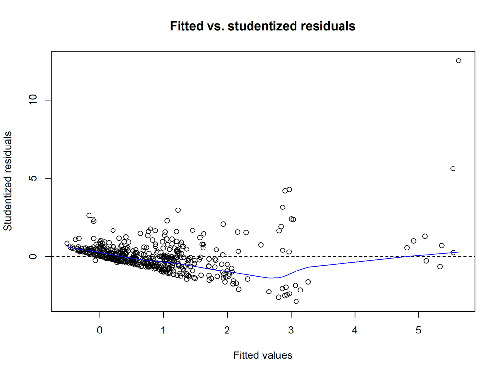

```r
plot(fitted(model1), studres(model1),
     xlab = "Fitted values",
     ylab = "Studentized residuals",
     main = "Fitted vs. studentized residuals")
abline(h = 0, lty = 2)
lines(lowess(fitted(model1),
      studres(model1)),
      col = "blue")
```

We continue with plots of predictors against studentized residuals.

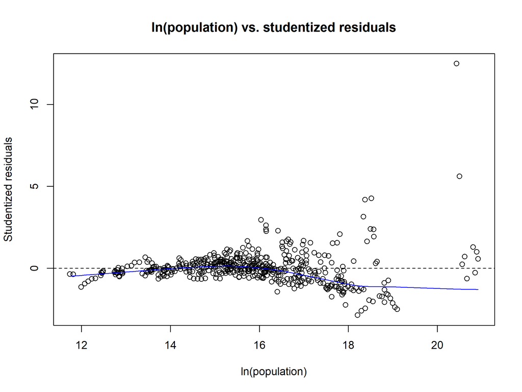

```r
plot(df_aid_trim$lnpop, studres(model1),
     xlab = "ln(population)",
     ylab = "Studentized residuals",
     main = "ln(population) vs. studentized residuals")
abline(h = 0, lty = 2)
lines(lowess(df_aid_trim$lnpop, studres(model1)),
      col = "blue")
```

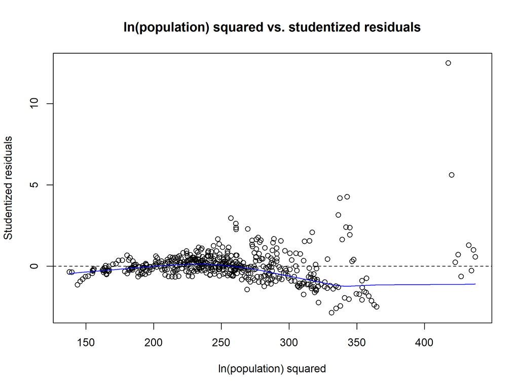

```r
plot(df_aid_trim$lnpopsq, studres(model1),
     xlab = "ln(population) squared",
     ylab = "Studentized residuals",
     main = "ln(population) squared vs. studentized residuals")
abline(h = 0, lty = 2)
lines(lowess(df_aid_trim$lnpopsq, studres(model1)),
      col = "blue")
```

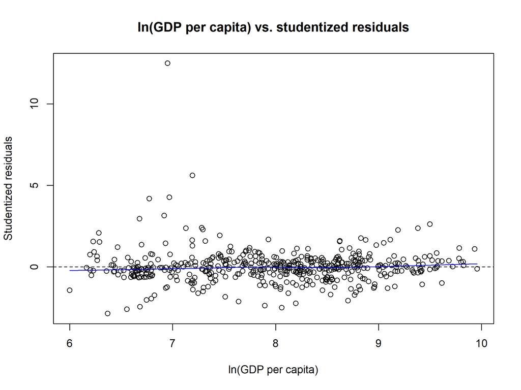

```r
plot(df_aid_trim$lngdp, studres(model1),
     xlab = "ln(GDP per capita)",
     ylab = "Studentized residuals",
     main = "ln(GDP per capita) vs. studentized residuals")
abline(h = 0, lty = 2)
lines(lowess(df_aid_trim$lngdp, studres(model1)),
      col = "blue")
```

If you want to inspect every predictor, please just modify the code with the new variable names. From what we’ve seen so far, though, it’s pretty clear that there is heteroskedasticity.

## 5.2 Statistical tests

Let’s follow the steps one by one for the Breusch-Pagan test. **First**, store the residuals from the model, and square them.

```r
df_aid_trim$residsq <- model1$residuals ^ 2
```

**Second**, run the regression using the squared residuals.

```r
model1star <- lm(residsq ~ lnpop + lnpopsq + lngdp +  lncolony +
                     lndist + freedom + militexp + arms + year83 +
                     year86 + year89 + year92,
                 data = df_aid_trim)
summary(model1star)
```

```
Call:
lm(formula = residsq ~ lnpop + lnpopsq + lngdp + lncolony + lndist +
    freedom + militexp + arms + year83 + year86 + year89 + year92,
    data = df_aid_trim)

Residuals:
    Min      1Q  Median      3Q     Max
-11.870  -0.987  -0.142   0.718  95.140

Coefficients:
             Estimate Std. Error t value   Pr(>|t|)
(Intercept) 59.284734  16.525193   3.588   0.000369 ***
lnpop       -8.013900   1.862923  -4.302 0.00002064 ***
lnpopsq      0.279260   0.057192   4.883 0.00000144 ***
lngdp       -0.506573   0.304810  -1.662   0.097197 .
lncolony     0.193984   0.087767   2.210   0.027573 *
lndist      -0.084576   0.486633  -0.174   0.862100
freedom      0.214572   0.077609   2.765   0.005921 **
militexp     0.003309   0.024516   0.135   0.892703
arms         0.039869   0.032133   1.241   0.215327
year83       1.722899   0.756895   2.276   0.023281 *
year86       0.301800   0.727440   0.415   0.678420
year89       0.272312   0.685555   0.397   0.691391
year92       0.046361   0.635852   0.073   0.941908
---
Signif. codes:  0 '***' 0.001 '**' 0.01 '*' 0.05 '.' 0.1 ' ' 1

Residual standard error: 4.909 on 468 degrees of freedom
Multiple R-squared:  0.1678,    Adjusted R-squared:  0.1464
F-statistic: 7.862 on 12 and 468 DF,  p-value: 2.009e-13
```

You can draw the conclusion based on the coefficients themselves - residuals are associated with predictors, which should not happen. However, the F-test result also suggests there is a problem of heteroskedasticity.

**Finally**, conduct a Lagrange-Multiplier test, which is (as its name suggests) a simple multiplication.

```r
dim(df_aid_trim)[1] * summary(model1star)$r.squared
```

```
[1] 80.69443
```

```r
rm(model1star)
```

There is also a canned solution, but it’s really very important to feel like you have control over some of these procedures.

```r
bptest(model1)
```

```
    studentized Breusch-Pagan test

data:  model1
BP = 80.694, df = 12, p-value = 0.000000000003042
```

# 6 Solution 1: Heteroskedasticity-consistent SEs

In Stata, it’s as easy as adding `, robust` to the regression command. R makes it a bit more difficult.[^1]

<sup>1</sup> This all changed with the creation of the `lm_robust()` function (which you can find in the `estimatr` package).

```r
model1$newse <- vcovHC(model1, # This is the function that takes the
                               # model's variance-covariance matrix,
                               # and computes one with SEs that are HC.
                       method = "white1", # General heteroskedasticity
                       type = "HC0")
```

It has a few arguments that allow it to produce some more sophisticated types of HC SEs, which are even more robust in the face of small samples. However, our sample is large enough that we can rely on the standard ones.

The `coeftest()` function from the `lmtest` package does a significance test based on the new variance-covariance matrix with HC SEs.

```r
coeftest(model1,          # old model object
         model1$newse)    # HC variance-covariance matrix
```

```
t test of coefficients:

              Estimate Std. Error t value       Pr(>|t|)
(Intercept) 24.9316385  5.4226436  4.5977 0.000005504312 ***
lnpop       -3.1323271  0.7023468 -4.4598 0.000010283348 ***
lnpopsq      0.1114200  0.0232831  4.7854 0.000002291136 ***
lngdp       -0.3966907  0.0645593 -6.1446 0.000000001716 ***
lncolony     0.0841268  0.0176992  4.7531 0.000002669629 ***
lndist      -0.0137612  0.0860643 -0.1599         0.8730
freedom      0.0356247  0.0197560  1.8032         0.0720 .
militexp     0.0025544  0.0043000  0.5940         0.5528
arms         0.0087505  0.0075095  1.1653         0.2445
year83       0.1623341  0.1911355  0.8493         0.3961
year86       0.0512047  0.1287429  0.3977         0.6910
year89       0.0974060  0.1207243  0.8068         0.4202
year92       0.0399221  0.0985962  0.4049         0.6857
---
Signif. codes:  0 '***' 0.001 '**' 0.01 '*' 0.05 '.' 0.1 ' ' 1
```

```r
# coeftest(model1,
#          481 / (481 - 12 - 1) * model1$newse)
```

It doesn’t come out as in the original analysis because this also included a correction for the degrees of freedom. If you want to get exact results, uncomment the code in the chunk above and run it.

Compare the two sets of results for a bit.

It’s extremely important to emphasize this: HC SEs do not do much to help you if other problems plague the model. If things like nonlinearity, specification error, or influential outliers exist, then it’s likely that the coefficients are biased. In this case, inefficient SEs should be the last of your worries.

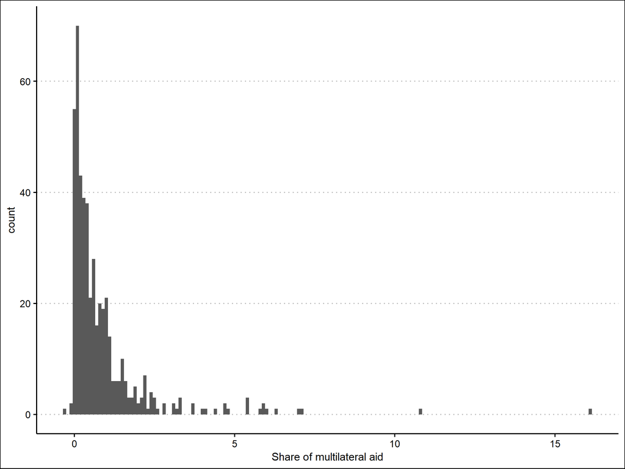

```r
ggplot(data = df_aid_trim,
       aes(x = multish)) +
       geom_histogram(binwidth = 0.1) +
       xlab("Share of multilateral aid") +
       theme_clean()
```

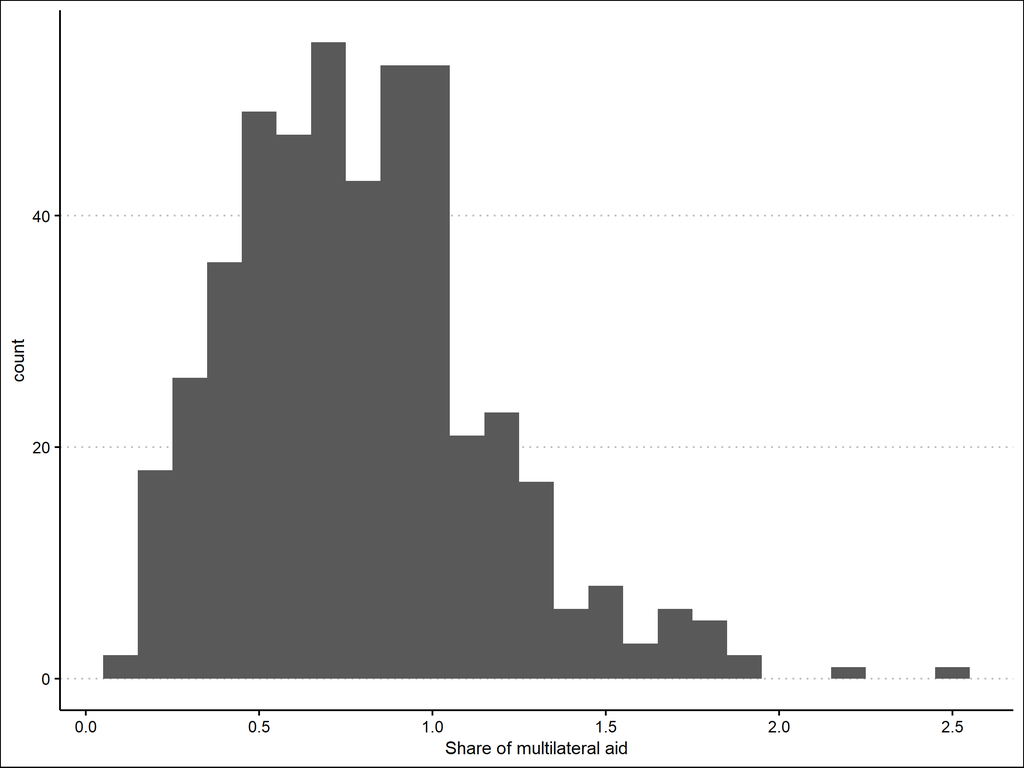

```r
df_aid_trim$transdv <- (df_aid_trim$multish)^(1/3)

ggplot(data = df_aid_trim,
       aes(x = transdv)) +
       geom_histogram(binwidth = 0.1) +
       xlab("Share of multilateral aid") +
       theme_clean()
```

An even better transformation is one from the Box-Cox family.

```r
df_aid_trim$transdv <- (df_aid_trim$multish ^ .18 - 1) / .18

model1star <- lm(transdv ~ lnpop + lnpopsq + lngdp +  lncolony +
                     lndist + freedom +militexp + arms + year83 +
                     year86 + year89 + year92,
                 data = df_aid_trim)
summary(model1star)
```

```
Call:
lm(formula = transdv ~ lnpop + lnpopsq + lngdp + lncolony + lndist +
    freedom + militexp + arms + year83 + year86 + year89 + year92,
    data = df_aid_trim)

Residuals:
     Min       1Q   Median       3Q      Max
-2.47975 -0.54488  0.02737  0.56305  2.42270

Coefficients:
             Estimate Std. Error t value     Pr(>|t|)
(Intercept) -4.540792   2.879424  -1.577       0.1155
lnpop        0.553065   0.324521   1.704       0.0890 .
lnpopsq     -0.003920   0.009962  -0.393       0.6941
lngdp       -0.489827   0.053238  -9.201      < 2e-16 ***
lncolony     0.084385   0.015446   5.463 0.0000000766 ***
lndist      -0.038294   0.086100  -0.445       0.6567
freedom      0.022794   0.013563   1.681       0.0935 .
militexp    -0.008830   0.004269  -2.068       0.0392 *
arms         0.008544   0.005596   1.527       0.1275
year83      -0.025638   0.132418  -0.194       0.8466
year86      -0.050588   0.127143  -0.398       0.6909
year89      -0.022966   0.119367  -0.192       0.8475
year92      -0.004245   0.111540  -0.038       0.9697
---
Signif. codes:  0 '***' 0.001 '**' 0.01 '*' 0.05 '.' 0.1 ' ' 1

Residual standard error: 0.8538 on 462 degrees of freedom
  (6 observations deleted due to missingness)
Multiple R-squared:  0.525, Adjusted R-squared:  0.5127
F-statistic: 42.56 on 12 and 462 DF,  p-value: < 2.2e-16
```

We can now compare these with the result we would obtain if we applied heteroskedasticity-consistent SEs.

```r
model1star$newse <- vcovHC(model1star,
                           method = "white1",
                           type = "HC0")
coeftest(model1star,
         model1star$newse)
```

```
t test of coefficients:

              Estimate Std. Error t value  Pr(>|t|)
(Intercept) -4.5407922  2.9418300 -1.5435   0.12339
lnpop        0.5530648  0.3308311  1.6717   0.09525 .
lnpopsq     -0.0039198  0.0102683 -0.3817   0.70283
lngdp       -0.4898273  0.0588960 -8.3168 1.022e-15 ***
lncolony     0.0843850  0.0160158  5.2689 2.110e-07 ***
lndist      -0.0382940  0.0965227 -0.3967   0.69175
freedom      0.0227938  0.0138244  1.6488   0.09987 .
militexp    -0.0088296  0.0043380 -2.0354   0.04238 *
arms         0.0085441  0.0048157  1.7742   0.07669 .
year83      -0.0256384  0.1297047 -0.1977   0.84339
year86      -0.0505880  0.1232506 -0.4104   0.68167
year89      -0.0229660  0.1254096 -0.1831   0.85478
year92      -0.0042451  0.1073032 -0.0396   0.96846
---
Signif. codes:  0 '***' 0.001 '**' 0.01 '*' 0.05 '.' 0.1 ' ' 1
```

```r
rm(model1star, model1, df_aid_trim, df_aid)
```

Once correcting for some other problems with the model, heteroskedasticity-consistent SEs don’t do that much anymore, in this particular case.

# 7 Solution 2: Weighted Least Squares (WLS)

For this section we use a data set of over 2,000 individuals, for which we know their net financial wealth. The following variables are important for us:

1. `nettfa`: net total financial assets, in 1,000s USD
2. `age`: age in years
3. `male`: R. is male
4. `e401k`: R. is eligible for a 401k (defined-contribution pension account)

```r
df_fin <- read.dta13(file = "../02-data/13-401ksubs.dta",
                     convert.factors = FALSE)
```

The data set has over 9,000 individuals, but we are interested in the 2,017 who are single.

```r
df_fin %<>%
    filter(fsize == 1)
```

## 7.1 Initial model

```r
model2 <- lm(nettfa ~ age + agesq + male + inc + e401k,
             data = df_fin)
summary(model2)
```

```
Call:
lm(formula = nettfa ~ age + agesq + male + inc + e401k, data = df_fin)

Residuals:
    Min      1Q  Median      3Q     Max
-175.96  -14.12   -3.10    5.94 1111.73

Coefficients:
             Estimate Std. Error t value Pr(>|t|)
(Intercept)  1.498079  15.312272   0.098  0.92207
age         -1.596178   0.769831  -2.073  0.03826 *
agesq        0.029003   0.009035   3.210  0.00135 **
male         2.473321   2.048209   1.208  0.22736
inc          0.774132   0.061973  12.491  < 2e-16 ***
e401k        6.981118   2.134241   3.271  0.00109 **
---
Signif. codes:  0 '***' 0.001 '**' 0.01 '*' 0.05 '.' 0.1 ' ' 1

Residual standard error: 44.5 on 2011 degrees of freedom
Multiple R-squared:  0.128, Adjusted R-squared:  0.1258
F-statistic: 59.01 on 5 and 2011 DF,  p-value: < 2.2e-16
```

What does the Breusch-Pagan test tell us?

```r
bptest(model2)
```

```
    studentized Breusch-Pagan test

data:  model2
BP = 16.253, df = 5, p-value = 0.006158
```

The test is highly statistically significant, indicating that the null hypothesis of homoskedasticity can be safely rejected.

There is good reason to assume that the variance in financial wealth actually depends on income. There is not much to save in a bank account when one is just over the limit of poverty. On the other hand, at higher levels of income, we are likely to see a lot more diversity in savings.

## 7.2 WLS

So we assume that Var(`nettfa`|`income`) = $\sigma^2 \times income$. You can run this model in 2 ways. **First**, we can use the `lm()` function, but allow for a `weights =` argument.

```r
model2.1 <- lm(nettfa ~ age + agesq + male + inc + e401k,
               data = df_fin,
               weights = 1 / inc)
summary(model2.1)
```

```
Call:
lm(formula = nettfa ~ age + agesq + male + inc + e401k, data = df_fin,
    weights = 1/inc)

Weighted Residuals:
    Min      1Q  Median      3Q     Max
-26.638  -2.484  -0.792   0.938 178.083

Coefficients:
             Estimate Std. Error t value Pr(>|t|)
(Intercept) -1.407830  11.522209  -0.122  0.90277
age         -1.093903   0.577920  -1.893  0.05852 .
agesq        0.020009   0.006771   2.955  0.00316 **
male         1.838468   1.563929   1.176  0.23992
inc          0.742591   0.064577  11.499  < 2e-16 ***
e401k        5.255703   1.712957   3.068  0.00218 **
---
Signif. codes:  0 '***' 0.001 '**' 0.01 '*' 0.05 '.' 0.1 ' ' 1

Residual standard error: 7.066 on 2011 degrees of freedom
Multiple R-squared:  0.1116,    Adjusted R-squared:  0.1094
F-statistic: 50.51 on 5 and 2011 DF,  p-value: < 2.2e-16
```

**Second**, we can use the `gls()` function from the `nlme` package. This one actually uses ML estimation, but asymptotically the results will be the same.

```r
model2.2 <- gls(nettfa ~ age + agesq + male + inc + e401k,
                data = df_fin,
                weights = varFunc(~inc))
summary(model2.2)
```

```
Generalized least squares fit by REML
  Model: nettfa ~ age + agesq + male + inc + e401k
  Data: df_fin
       AIC      BIC    logLik
  20188.85 20228.09 -10087.42

Variance function:
 Structure: fixed weights
 Formula: ~inc

Coefficients:
                Value Std.Error   t-value p-value
(Intercept) -1.407830 11.522209 -0.122184  0.9028
age         -1.093903  0.577920 -1.892825  0.0585
agesq        0.020009  0.006771  2.955259  0.0032
male         1.838468  1.563929  1.175545  0.2399
inc          0.742591  0.064577 11.499325  0.0000
e401k        5.255703  1.712957  3.068204  0.0022

 Correlation:
      (Intr) age    agesq  male   inc
age   -0.979
agesq  0.956 -0.993
male  -0.056 -0.037  0.066
inc   -0.024 -0.087  0.083 -0.072
e401k  0.087 -0.106  0.105  0.059 -0.240

Standardized residuals:
       Min         Q1        Med         Q3        Max
-3.7695570 -0.3515172 -0.1120808  0.1326965 25.2010055

Residual standard error: 7.06649
Degrees of freedom: 2017 total; 2011 residual
```

```r
rm(model2, model2.1, model2.2, df_fin)
```

# 8 Solution 3: Feasible Generalized Least Squares (FGLS)

With the slide information, and the `gls()` function, you pretty much have all the information you need to run a FGLS procedure. Rather than simply repeat the same old story, I thought I’d show you a kind of rare, but very cool, application of a type of FGLS.

In this case of model, we actually know the variance structure. This is because we are trying to model an actual coefficient!

The data for this application comes from wave 3 of the **CSES**. My dependent variable is a composite index of political efficacy (internal + external efficacy), where higher values denote more political efficacy.

```r
df_cses3 <- readRDS(file = "../02-data/14-cses3-sub.rds")
```

```r
df_cses3 %<>%
    glimpse()
```

```
Rows: 80,163
Columns: 11
$ poleff    <dbl> 8, 10, 4, 7, 10, 9, 7, 8, 7, 10, 6, 5, 6, 10, 6, 8, 6, 6, 8,…
$ age       <dbl> 5.2, 0.2, 1.7, 6.0, 1.9, 4.1, 5.1, 3.3, 3.7, 0.9, 4.2, 4.8, …
$ female    <dbl> 0, 1, 0, 0, 1, 0, 0, 0, 1, 1, 0, 0, 1, 1, 0, 1, 1, 0, 1, 1, …
$ education <dbl> 2, 2, 7, 2, 2, 5, 2, 7, 2, NA, 7, NA, 2, 2, 5, 5, 7, 2, 7, 5…
$ union     <dbl> 0, 0, 0, 0, 0, 0, 1, 1, 0, 0, 1, 0, 0, 0, 0, 0, NA, 1, 0, 0,…
$ income    <dbl> 0, 4, 0, 0, 3, 4, 0, 3, 4, 1, 3, 0, 1, 4, 2, 3, 0, NA, 4, 3,…
$ majorit   <dbl> 1, 1, 1, 1, 1, 1, 1, 1, 1, 1, 1, 1, 1, 1, 1, 1, 1, 1, 1, 1, …
$ gdpcap    <dbl> 33.84811, 33.84811, 33.84811, 33.84811, 33.84811, 33.84811, …
$ gininet   <dbl> 31.776, 31.776, 31.776, 31.776, 31.776, 31.776, 31.776, 31.7…
$ cpi       <dbl> 8.6, 8.6, 8.6, 8.6, 8.6, 8.6, 8.6, 8.6, 8.6, 8.6, 8.6, 8.6, …
$ C1004     <fct> AUS_2007, AUS_2007, AUS_2007, AUS_2007, AUS_2007, AUS_2007, …
```

## 8.1 Codebook

Variables in the data:

1. `age`: measured in decades
2. `female`: dichotomous indicator (1 = *yes*)
3. `education`: educational level, where 0 = *none* and 7 = *BA completed*
4. `union`: union member (1 = *yes*)
5. `income`: income quintile, from 0 to 4
6. `majorit`: country has a majoritarian electoral system
7. `gdpcap`: GDP per capita in the country
8. `gininet`: Gini index of net income inequality in the country
9. `cpi`: TI’s corruption perception index
10. `C1004`: country-year indicator

It might come as a suprise, but this modeling strategy is actually asymptotically equivalent to a multilevel model.